# AOL CODE

2802421135_Ernestine

2025-06-11

#library

```r
library(RColorBrewer)
library(stringr)
library(dplyr)
```

```r
library(plotly)
library(ggplot2)
```

# import show head

```r
dt= read.csv("D:/00semester 2/DMV/Waste-Collection-Volume.csv")
head(dt)
```

```
##   bulan                                titik_lokasi  kecamatan       wilayah
## 1     1      Kali / Sungai Sentiong - Ruas Dewi Sri Johar Baru Jakarta Pusat
## 2     1        Kali / Sungai Sentiong - Ruas Abapon Johar Baru Jakarta Pusat
## 3     1    Kali / Sungai Sentiong - JL Tanah Tinggi Johar Baru Jakarta Pusat
## 4     1 Kali / Sungai Sentiong Jl.Galur - Pombensin Johar Baru Jakarta Pusat
## 5     1          Kali / Sungai Sentiong - Jl. Timah Johar Baru Jakarta Pusat
## 6     1                         PHB Kawi Kawi Bawah Johar Baru Jakarta Pusat
##   panjang.luas satuan_panjang.luas tanggal volume_sampah_perhari.m3.
## 1          464                   m       1                         4
## 2          464                   m       1                         4
## 3          464                   m       1                         4
## 4          606                   m       1                         4
## 5          310                   m       1                         7
## 6          620                   m       1                         1
```

# Cek ringkasan data untuk memahami struktur dan mendeteksi nilai yang tidak valid atau missing

```r
summary(dt)
```

```
##      bulan   titik_lokasi        kecamatan           wilayah
##  Min.   :1   Length:54343       Length:54343       Length:54343
##  1st Qu.:1   Class :character   Class :character   Class :character
##  Median :1   Mode  :character   Mode  :character   Mode  :character
##  Mean   :1
##  3rd Qu.:1
##  Max.   :1
##  panjang.luas       satuan_panjang.luas    tanggal   volume_sampah_perhari.m3.
##  Length:54343       Length:54343        Min.   : 1   Length:54343
##  Class :character   Class :character    1st Qu.: 8   Class :character
##  Mode  :character   Mode  :character    Median :16   Mode  :character
##                                         Mean   :16
##                                         3rd Qu.:24
##                                         Max.   :31
```

# Cek informasi lebih lanjut tentang kolom dan tipe data

```r
str(dt)
```

```
## 'data.frame':    54343 obs. of  8 variables:
##  $ bulan                    : int  1 1 1 1 1 1 1 1 1 1 ...
##  $ titik_lokasi             : chr  "Kali / Sungai Sentiong - Ruas Dewi Sri" "Kali / Sungai Sentiong - Ruas Abapon" "Kali / Sungai Sentiong - JL Tanah Tinggi" "Kali / Sungai Sentiong Jl.Galur - Pombensin" ...
##  $ kecamatan                : chr  "Johar Baru" "Johar Baru" "Johar Baru" "Johar Baru" ...
##  $ wilayah                  : chr  "Jakarta Pusat" "Jakarta Pusat" "Jakarta Pusat" "Jakarta Pusat" ...
##  $ panjang.luas             : chr  "464" "464" "464" "606" ...
##  $ satuan_panjang.luas      : chr  "m" "m" "m" "m" ...
##  $ tanggal                  : int  1 1 1 1 1 1 1 1 1 1 ...
##  $ volume_sampah_perhari.m3.: chr  "4" "4" "4" "4" ...
```

# Preprocessing kolom panjang luas

##### Cek nilai unik

```r
unique(dt$panjang.luas)
```

```
##   [1] "464"      "606"      "310"      "620"      "300"      "500"
##   [7] "330"      "200"      "600"      "400"      "950"      "1250"
##  [13] "700"      "900"      "1100"     "860"      "1570"     "250"
##  [19] "210"      "220"      "680"      "550"      "2000"     "1000"
##  [25] "800"      "1500"     "4"        "100"      "650"      "750"
##  [31] ""         "3500"     "14.15"    "150"      "6"        "12000"
##  [37] "2500"     "3500/70"  "1400/10"  "1100/10"  "1000/10"  "700/10"
##  [43] "3000/15"  "36800"    "36617"    "1000/7"   "700/15"   "1000/6"
##  [49] "700/6"    "800/7"    "1000/8"   "Jun-00"   "Oct-00"   "1000/5"
##  [55] "2000/15"  "May-00"   "1000/4"   "1"        "1500/10"  "Apr-00"
##  [61] "700/8"    "800/4"    "1000/30"  "700/5"    "700/4"    "700/3"
##  [67] "1000/3"   "900/5"    "500/6"    "500/10"   "300/3"    "500/5"
##  [73] "3000/32"  "1000/2"   "200/17"   "500/3"    "500/4"    "500/8"
##  [79] "600/3"    "600/5"    "2000/3.5" "800/3"    "8"        "1500/35"
##  [85] "1300/35"  "900/35"   "1000/35"  "900/10"   "600/4"    "1200/5"
```

[output cut: 59 more lines]

##### cek untuk input yang formatnya seperti “100/4”, apa satuannya

```r
# Filter data untuk mengambil yang memiliki tanda '/' pada panjang.luas dan melihat satuan_panjang.luas
dt1<- dt %>%
  filter(grepl("/", dt$panjang.luas))

# Menampilkan nilai unik dari satuan_panjang.luas untuk data yang sudah difilter
unique(dt1$satuan_panjang.luas)
```

```
## [1] ""
```

```r
head(dt1)
```

```
##   bulan                         titik_lokasi kecamatan       wilayah
## 1     1 Kali BKT Marunda Pintu Air Sekatan 1 Cilincing Jakarta Utara
## 2     1 Kali BKT Marunda Pintu Air Sekatan 2 Cilincing Jakarta Utara
## 3     1          Kali Cakung Drain Sekatan 1 Cilincing Jakarta Utara
## 4     1          Kali Cakung Drain Sekatan 2 Cilincing Jakarta Utara
## 5     1              Kali Muara Cakung Drain Cilincing Jakarta Utara
## 6     1     Kali Bangleo Kelurahan Kali Baru Cilincing Jakarta Utara
##   panjang.luas satuan_panjang.luas tanggal volume_sampah_perhari.m3.
## 1      3500/70                           1                         6
## 2      1400/10                           1                         6
## 3      1100/10                           1                         0
## 4      1000/10                           1                         0
## 5      1000/10                           1                         0
## 6      1000/10                           1                         0
```

ternyata gaada satuaanya

kita ambil angka sebelum “/” lalu berikan satuan m

```r
# Memperbarui kolom satuan_panjang.luas menjadi "m" jika panjang.luas mengandung "/" dan satuan_panjang.luas kosong
dt2 <- dt %>%
  mutate(
    satuan_panjang.luas = ifelse(grepl("/", panjang.luas), "m", satuan_panjang.luas)
  )
head(dt2)
```

```
##   bulan                                titik_lokasi  kecamatan       wilayah
## 1     1      Kali / Sungai Sentiong - Ruas Dewi Sri Johar Baru Jakarta Pusat
## 2     1        Kali / Sungai Sentiong - Ruas Abapon Johar Baru Jakarta Pusat
## 3     1    Kali / Sungai Sentiong - JL Tanah Tinggi Johar Baru Jakarta Pusat
## 4     1 Kali / Sungai Sentiong Jl.Galur - Pombensin Johar Baru Jakarta Pusat
## 5     1          Kali / Sungai Sentiong - Jl. Timah Johar Baru Jakarta Pusat
## 6     1                         PHB Kawi Kawi Bawah Johar Baru Jakarta Pusat
##   panjang.luas satuan_panjang.luas tanggal volume_sampah_perhari.m3.
## 1          464                   m       1                         4
## 2          464                   m       1                         4
## 3          464                   m       1                         4
## 4          606                   m       1                         4
## 5          310                   m       1                         7
## 6          620                   m       1                         1
```

cek lagi

```r
# Filter data untuk mengambil yang memiliki tanda '/' pada panjang.luas dan melihat satuan_panjang.luas
dt3<- dt2 %>%
  filter(grepl("/", dt2$panjang.luas))

# Menampilkan nilai unik dari satuan_panjang.luas untuk data yang sudah difilter
unique(dt3$satuan_panjang.luas)
```

```
## [1] "m"
```

```r
head(dt3)
```

```
##   bulan                         titik_lokasi kecamatan       wilayah
## 1     1 Kali BKT Marunda Pintu Air Sekatan 1 Cilincing Jakarta Utara
## 2     1 Kali BKT Marunda Pintu Air Sekatan 2 Cilincing Jakarta Utara
## 3     1          Kali Cakung Drain Sekatan 1 Cilincing Jakarta Utara
## 4     1          Kali Cakung Drain Sekatan 2 Cilincing Jakarta Utara
## 5     1              Kali Muara Cakung Drain Cilincing Jakarta Utara
## 6     1     Kali Bangleo Kelurahan Kali Baru Cilincing Jakarta Utara
##   panjang.luas satuan_panjang.luas tanggal volume_sampah_perhari.m3.
## 1      3500/70                   m       1                         6
## 2      1400/10                   m       1                         6
## 3      1100/10                   m       1                         0
## 4      1000/10                   m       1                         0
## 5      1000/10                   m       1                         0
## 6      1000/10                   m       1                         0
```

```r
# Ambil angka sebelum "/" jika ada, jika tidak, biarkan angka tersebut tetap seperti semula
dt3 <- dt2 %>%
  mutate(
    panjang.luas = ifelse(
      grepl("/", panjang.luas),  # Cek apakah ada "/"
      str_extract(panjang.luas, "^[^/]+"),  # Ambil angka sebelum "/"
      panjang.luas  # Jika tidak ada "/", biarkan nilai tetap
    )
  )

# Menampilkan data yang sudah diperbarui
unique(dt3$panjang.luas)
```

```
##   [1] "464"    "606"    "310"    "620"    "300"    "500"    "330"    "200"
##   [9] "600"    "400"    "950"    "1250"   "700"    "900"    "1100"   "860"
##  [17] "1570"   "250"    "210"    "220"    "680"    "550"    "2000"   "1000"
##  [25] "800"    "1500"   "4"      "100"    "650"    "750"    ""       "3500"
##  [33] "14.15"  "150"    "6"      "12000"  "2500"   "1400"   "3000"   "36800"
##  [41] "36617"  "Jun-00" "Oct-00" "May-00" "1"      "Apr-00" "8"      "1300"
##  [49] "1200"   "450"    "350"    "751"    "1800"   "2"      "50"     "May-50"
##  [57] "10"     "9"      "432"    "435"    "6.5"    "1900"   "15"     "80"
##  [65] "3"      "Apr-50" "Apr-21" "2200"   "800m"   "0.9"    "1.5"    "610"
##  [73] "0.0875" "755"    "663"    "522"    "795"    "745"    "925"    "24"
##  [81] "392"    "320"    "1968"   "573"    "31.5"   "360"    "331"    "1070"
##  [89] "1172"   "1502"   "839"    "627"    "1320"   "420"    "1359"   "1247"
##  [97] "1642"   "1120"   "1060"   "1820"   "1350"   "821"    "2700"   "1550"
## [105] "1360"   "815"    "780"    "1450"   "1750"   "1102"   "850"    "2.5"
## [113] "325"    "5"      "230"    "239"    "283"    "245"    "297"    "307"
```

[output cut: 20 more lines]

##### cek yg inputannya ada huruf itu ada berapa dan satuannya apa

cek jmlh data

```r
filtered_data <- dt3 %>%
  filter(grepl("Apr-00|May-50|Jun-00|Oct-00|May-00|Apr-50|Apr-21", panjang.luas))
nrow(filtered_data)
```

```
## [1] 310
```

cek satuan

```r
unique(filtered_data$satuan_panjang.luas)
```

```
## [1] ""
```

kosong

cek wilayah

```r
unique(filtered_data$wilayah)
```

```
## [1] "Jakarta Utara"
```

```r
head(filtered_data)
```

```
##   bulan                           titik_lokasi kecamatan       wilayah
## 1     1                      PHB Tanah Merdeka Cilincing Jakarta Utara
## 2     1                          PHB Gang Sate Cilincing Jakarta Utara
## 3     1                              PHB Pos 5 Cilincing Jakarta Utara
## 4     1 PHB Pintu Dua Pegangsaan Kel. Sukapura Cilincing Jakarta Utara
## 5     1               Inlet 1 Waduk Rawa Badak      Koja Jakarta Utara
## 6     1               Inlet 2 Waduk Rawa Badak      Koja Jakarta Utara
##   panjang.luas satuan_panjang.luas tanggal volume_sampah_perhari.m3.
## 1       Jun-00                           1                         0
## 2       Oct-00                           1                         0
## 3       May-00                           1                         0
## 4       Apr-00                           1                         0
## 5       May-50                           1                         6
## 6       May-50                           1                         6
```

mau lihat jakut ada berapa data

```r
# Menyaring data yang memiliki "Jakarta Utara" di kolom wilayah
jakarta_utara_data <- dt3 %>%
  filter(wilayah == "Jakarta Utara")

# Menampilkan jumlah baris yang ditemukan
nrow(jakarta_utara_data)
```

```
## [1] 12989
```

brti 310 data masih aman dihapus krn cmn 2% dari wilayah jakut

##### hapus yang input “bulan-angka”

```r
dt4 <- dt3 %>%
  filter(!grepl("Apr-00|May-50|Jun-00|Oct-00|May-00|Apr-50|Apr-21", panjang.luas))

nrow(dt4)
```

```
## [1] 54033
```

cek unik kolom panjang.luas

```r
unique(dt4$panjang.luas)
```

```
##   [1] "464"    "606"    "310"    "620"    "300"    "500"    "330"    "200"
##   [9] "600"    "400"    "950"    "1250"   "700"    "900"    "1100"   "860"
##  [17] "1570"   "250"    "210"    "220"    "680"    "550"    "2000"   "1000"
##  [25] "800"    "1500"   "4"      "100"    "650"    "750"    ""       "3500"
##  [33] "14.15"  "150"    "6"      "12000"  "2500"   "1400"   "3000"   "36800"
##  [41] "36617"  "1"      "8"      "1300"   "1200"   "450"    "350"    "751"
##  [49] "1800"   "2"      "50"     "10"     "9"      "432"    "435"    "6.5"
##  [57] "1900"   "15"     "80"     "3"      "2200"   "800m"   "0.9"    "1.5"
##  [65] "610"    "0.0875" "755"    "663"    "522"    "795"    "745"    "925"
##  [73] "24"     "392"    "320"    "1968"   "573"    "31.5"   "360"    "331"
##  [81] "1070"   "1172"   "1502"   "839"    "627"    "1320"   "420"    "1359"
##  [89] "1247"   "1642"   "1120"   "1060"   "1820"   "1350"   "821"    "2700"
##  [97] "1550"   "1360"   "815"    "780"    "1450"   "1750"   "1102"   "850"
## [105] "2.5"    "325"    "5"      "230"    "239"    "283"    "245"    "297"
## [113] "307"    "186"    "266"    "163"    "311"    "395"    "101"    "271"
```

[output cut: 19 more lines]

tinggal handling yg angka ada m misal “800m”, kosong, “-”, “1Ha”

##### cek yg input format “angkam” misal “800m” itu ada berapa dan satuannya apa

cek jmlh data

```r
pilter <- dt4 %>%
  filter(grepl("800m|500m|600m|400m", panjang.luas))
nrow(pilter)
```

```
## [1] 279
```

cek satuan_panjang.luas

```r
unique(pilter$satuan_panjang.luas)
```

```
## [1] ""
```

kosong semua brti kita ambil angkanya trus utk kolom satuan kita isi “m”

```r
# Memperbarui kolom satuan_panjang.luas menjadi "m" jika panjang.luas mengandung "m"
dt5 <- dt4 %>%
  mutate(
    satuan_panjang.luas = ifelse(grepl("m", panjang.luas), "m", satuan_panjang.luas)
  )
head(dt5)
```

```
##   bulan                                titik_lokasi  kecamatan       wilayah
## 1     1      Kali / Sungai Sentiong - Ruas Dewi Sri Johar Baru Jakarta Pusat
## 2     1        Kali / Sungai Sentiong - Ruas Abapon Johar Baru Jakarta Pusat
## 3     1    Kali / Sungai Sentiong - JL Tanah Tinggi Johar Baru Jakarta Pusat
## 4     1 Kali / Sungai Sentiong Jl.Galur - Pombensin Johar Baru Jakarta Pusat
## 5     1          Kali / Sungai Sentiong - Jl. Timah Johar Baru Jakarta Pusat
## 6     1                         PHB Kawi Kawi Bawah Johar Baru Jakarta Pusat
##   panjang.luas satuan_panjang.luas tanggal volume_sampah_perhari.m3.
## 1          464                   m       1                         4
## 2          464                   m       1                         4
## 3          464                   m       1                         4
## 4          606                   m       1                         4
## 5          310                   m       1                         7
## 6          620                   m       1                         1
```

cek apakah satuan ufh keubah jadi m

```r
pilter1 <- dt5 %>%
  filter(grepl("800m|500m|600m|400m", panjang.luas))
head(pilter1)
```

```
##   bulan
## 1     1
## 2     1
## 3     1
## 4     1
## 5     1
## 6     1
##                                                                 titik_lokasi
## 1   Kali Anak Angke Kp Salo Perumahan Grand Garden Residence Kembangan Utara
## 2     Kali PHB Perumahan Grend Garden JL Teratai Rt 07 Rw 04 Kembangan Utara
## 3 Kali PHB Perumahan Grend Garden Jl Basmol Raya Rt 08 Rw 04 Kembangan Utara
## 4                 Kali Citegal Alur (Jembatan Lingkungan 3 - Jembatan Tempe)
## 5                                               PHB Ps.Timbul - PHB Sukatani
## 6                   Kali Citegal Alur (Jembatan Risma - Jembatan GG.Jenggot)
##   kecamatan       wilayah panjang.luas satuan_panjang.luas tanggal
## 1 Kembangan Jakarta Barat         800m                   m       1
## 2 Kembangan Jakarta Barat         800m                   m       1
## 3 Kembangan Jakarta Barat         800m                   m       1
## 4 Kalideres Jakarta Barat         500m                   m       1
## 5 Kalideres Jakarta Barat         500m                   m       1
## 6 Kalideres Jakarta Barat         600m                   m       1
##   volume_sampah_perhari.m3.
## 1                        12
## 2                         -
## 3                        12
## 4                         -
## 5                         1
## 6                         1
```

oke udah keubah, skrng kita ambil angka di blkng “m” di kolom panjang luas

```r
# Ambil angka sebelum "m" jika ada, jika tidak, biarkan tetap seperti semula
dt6 <- dt5 %>%
  mutate(
    panjang.luas = ifelse(
      grepl("m", panjang.luas),  # Cek apakah ada "m"
      str_extract(panjang.luas, "^[^m]+"),  # Ambil angka sebelum "m"
      panjang.luas  # Jika tidak ada "m", biarkan
    )
  )

# Menampilkan data yang sudah diperbarui
unique(dt6$panjang.luas)
```

```
##   [1] "464"    "606"    "310"    "620"    "300"    "500"    "330"    "200"
##   [9] "600"    "400"    "950"    "1250"   "700"    "900"    "1100"   "860"
##  [17] "1570"   "250"    "210"    "220"    "680"    "550"    "2000"   "1000"
##  [25] "800"    "1500"   "4"      "100"    "650"    "750"    ""       "3500"
##  [33] "14.15"  "150"    "6"      "12000"  "2500"   "1400"   "3000"   "36800"
##  [41] "36617"  "1"      "8"      "1300"   "1200"   "450"    "350"    "751"
##  [49] "1800"   "2"      "50"     "10"     "9"      "432"    "435"    "6.5"
##  [57] "1900"   "15"     "80"     "3"      "2200"   "0.9"    "1.5"    "610"
##  [65] "0.0875" "755"    "663"    "522"    "795"    "745"    "925"    "24"
##  [73] "392"    "320"    "1968"   "573"    "31.5"   "360"    "331"    "1070"
##  [81] "1172"   "1502"   "839"    "627"    "1320"   "420"    "1359"   "1247"
##  [89] "1642"   "1120"   "1060"   "1820"   "1350"   "821"    "2700"   "1550"
##  [97] "1360"   "815"    "780"    "1450"   "1750"   "1102"   "850"    "2.5"
## [105] "325"    "5"      "230"    "239"    "283"    "245"    "297"    "307"
## [113] "186"    "266"    "163"    "311"    "395"    "101"    "271"    "246"
```

[output cut: 19 more lines]

tinggal handling yg kosong, “-”, “1Ha”

cek status data skrg

```r
summary(dt6)
```

```
##      bulan   titik_lokasi        kecamatan           wilayah
##  Min.   :1   Length:54033       Length:54033       Length:54033
##  1st Qu.:1   Class :character   Class :character   Class :character
##  Median :1   Mode  :character   Mode  :character   Mode  :character
##  Mean   :1
##  3rd Qu.:1
##  Max.   :1
##  panjang.luas       satuan_panjang.luas    tanggal   volume_sampah_perhari.m3.
##  Length:54033       Length:54033        Min.   : 1   Length:54033
##  Class :character   Class :character    1st Qu.: 8   Class :character
##  Mode  :character   Mode  :character    Median :16   Mode  :character
##                                         Mean   :16
##                                         3rd Qu.:24
##                                         Max.   :31
```

##### hapus yang “-” dan “”

```r
dt7<- dt6 %>%
  filter(!grepl("-", panjang.luas) & nchar(panjang.luas) > 0)
nrow(dt7)
```

```
## [1] 53134
```

cek uniq

```r
unique(dt7$panjang.luas)
```

```
##   [1] "464"    "606"    "310"    "620"    "300"    "500"    "330"    "200"
##   [9] "600"    "400"    "950"    "1250"   "700"    "900"    "1100"   "860"
##  [17] "1570"   "250"    "210"    "220"    "680"    "550"    "2000"   "1000"
##  [25] "800"    "1500"   "4"      "100"    "650"    "750"    "3500"   "14.15"
##  [33] "150"    "6"      "12000"  "2500"   "1400"   "3000"   "36800"  "36617"
##  [41] "1"      "8"      "1300"   "1200"   "450"    "350"    "751"    "1800"
##  [49] "2"      "50"     "10"     "9"      "432"    "435"    "6.5"    "1900"
##  [57] "15"     "80"     "3"      "2200"   "0.9"    "1.5"    "610"    "0.0875"
##  [65] "755"    "663"    "522"    "795"    "745"    "925"    "24"     "392"
##  [73] "320"    "1968"   "573"    "31.5"   "360"    "331"    "1070"   "1172"
##  [81] "1502"   "839"    "627"    "1320"   "420"    "1359"   "1247"   "1642"
##  [89] "1120"   "1060"   "1820"   "1350"   "821"    "2700"   "1550"   "1360"
##  [97] "815"    "780"    "1450"   "1750"   "1102"   "850"    "2.5"    "325"
## [105] "5"      "230"    "239"    "283"    "245"    "297"    "307"    "186"
## [113] "266"    "163"    "311"    "395"    "101"    "271"    "246"    "585"
```

[output cut: 18 more lines]

tinggal handling “1Ha”

##### cek “1Ha”

```r
pilter2 <- dt7 %>%
  filter(grepl("1Ha", panjang.luas))
nrow(pilter2)
```

```
## [1] 62
```

cek wilayahny

```r
unique(pilter2$wilayah)
```

```
## [1] "Jakarta Selatan"
```

mau lihat jaksel ada berapa data

```r
jakarta_selatan_data <- dt7 %>%
  filter(wilayah == "Jakarta Selatan")

nrow(jakarta_selatan_data)
```

```
## [1] 8091
```

oke hapus

```r
dt8 <- dt7 %>%
  filter(!grepl("1Ha", panjang.luas))
nrow(dt8)
```

```
## [1] 53072
```

#Preprocessing kolom satuan panjang luas

##### cek jumlah yang satuannya kosong

```r
pilterr = dt8 %>%
  filter(nchar(satuan_panjang.luas)<1)

nrow(pilterr)
```

```
## [1] 8656
```

yang kosong kita ubah ke meter

##### ubah kosong ke meter

```r
dt9 <- dt8 %>%
  mutate(satuan_panjang.luas = ifelse(nchar(satuan_panjang.luas) < 1, "m", satuan_panjang.luas))

# Menampilkan jumlah baris yang memiliki satuan kosong setelah penggantian
pilterr <- dt9 %>%
  filter(nchar(satuan_panjang.luas) < 1)

nrow(pilterr)
```

```
## [1] 0
```

##### hapuus data selain dengan satuan meter

```r
dt10 = dt9 %>%
  filter(satuan_panjang.luas == "m" | satuan_panjang.luas == "M")
head(dt10)
```

```
##   bulan                                titik_lokasi  kecamatan       wilayah
## 1     1      Kali / Sungai Sentiong - Ruas Dewi Sri Johar Baru Jakarta Pusat
## 2     1        Kali / Sungai Sentiong - Ruas Abapon Johar Baru Jakarta Pusat
## 3     1    Kali / Sungai Sentiong - JL Tanah Tinggi Johar Baru Jakarta Pusat
## 4     1 Kali / Sungai Sentiong Jl.Galur - Pombensin Johar Baru Jakarta Pusat
## 5     1          Kali / Sungai Sentiong - Jl. Timah Johar Baru Jakarta Pusat
## 6     1                         PHB Kawi Kawi Bawah Johar Baru Jakarta Pusat
##   panjang.luas satuan_panjang.luas tanggal volume_sampah_perhari.m3.
## 1          464                   m       1                         4
## 2          464                   m       1                         4
## 3          464                   m       1                         4
## 4          606                   m       1                         4
## 5          310                   m       1                         7
## 6          620                   m       1                         1
```

```r
summary(dt10)
```

```
##      bulan   titik_lokasi        kecamatan           wilayah
##  Min.   :1   Length:51491       Length:51491       Length:51491
##  1st Qu.:1   Class :character   Class :character   Class :character
##  Median :1   Mode  :character   Mode  :character   Mode  :character
##  Mean   :1
##  3rd Qu.:1
##  Max.   :1
##  panjang.luas       satuan_panjang.luas    tanggal   volume_sampah_perhari.m3.
##  Length:51491       Length:51491        Min.   : 1   Length:51491
##  Class :character   Class :character    1st Qu.: 8   Class :character
##  Mode  :character   Mode  :character    Median :16   Mode  :character
##                                         Mean   :16
##                                         3rd Qu.:24
##                                         Max.   :31
```

```r
dt10 <- dt10 %>% rename(panjang = panjang.luas)
```

```r
unique(dt10$wilayah)
```

```
## [1] "Jakarta Pusat"   "Jakarta Utara"   "Jakarta Barat"   "Jakarta Selatan"
## [5] "Jakarta Timur"
```

```r
unique(dt10$panjang)
```

```
##   [1] "464"   "606"   "310"   "620"   "300"   "500"   "330"   "200"   "600"
##  [10] "400"   "950"   "1250"  "700"   "900"   "1100"  "860"   "1570"  "250"
##  [19] "210"   "220"   "680"   "550"   "2000"  "1000"  "800"   "1500"  "4"
##  [28] "100"   "650"   "750"   "3500"  "14.15" "150"   "12000" "2500"  "1400"
##  [37] "3000"  "36800" "36617" "1300"  "1200"  "450"   "350"   "751"   "1800"
##  [46] "50"    "432"   "435"   "1900"  "2200"  "610"   "755"   "663"   "522"
##  [55] "795"   "745"   "925"   "392"   "320"   "1968"  "573"   "31.5"  "360"
##  [64] "331"   "1070"  "1172"  "1502"  "839"   "627"   "1320"  "420"   "1359"
##  [73] "1247"  "1642"  "1120"  "1060"  "1820"  "1350"  "821"   "2700"  "1550"
##  [82] "1360"  "815"   "780"   "1450"  "1750"  "1102"  "850"   "2.5"   "325"
##  [91] "230"   "239"   "283"   "245"   "297"   "307"   "186"   "266"   "163"
## [100] "311"   "395"   "101"   "271"   "246"   "585"   "365"   "290"   "380"
## [109] "390"   "425"   "1190"  "471"   "1090"  "861"   "445"   "1420"  "852"
## [118] "553"   "496"   "1590"  "835"   "907"   "457"   "1580"  "834"   "1150"
## [127] "560"   "628"   "1180"  "914"   "475"   "265"   "490"   "505"   "668"
## [136] "556"   "632"   "806"   "588"   "712"   "732"   "1380"  "723"   "555"
## [145] "1540"  "540"   "642"   "658"   "918"   "541"   "441"   "1230"  "1160"
## [154] "366"   "472"   "823"   "804"   "796"   "215"   "742"   "866"   "486"
## [163] "1783"  "626"   "280"   "1074"  "1685"  "4500"  "649"   "565"   "469"
## [172] "719"   "634"   "544"   "956"   "436"   "868"   "635"   "1406"  "570"
## [181] "643"   "421"   "1465"  "403"   "687"   "820"   "480"   "275"   "337"
## [190] "909"   "662"   "2527"  "4000"  "2181"  "978"   "1099"  "4060"  "2100"
## [199] "1501"  "898"   "1593"  "3900"  "6000"  "1600"  "1201"  "738"   "1454"
## [208] "1071"  "3700"  "5300"  "785"   "911"   "3197"  "488"   "5000"  "756"
## [217] "4700"  "430"   "1.07"  "1.172" "1.502" "1"     "1.32"  "1.359" "1.247"
## [226] "1.642" "1.12"  "1.82"  "1.2"   "1.35"  "1.3"   "2.7"   "1.55"  "1.36"
## [235] "1.1"   "1.8"   "1.45"  "1.75"  "1.102"
```

cek jmlh data yang panjangnya <10

```r
piltere = dt10 %>%
  filter(panjang <10)
nrow(piltere)
```

```
## [1] 810
```

hapus krn ga masuk akal

```r
dt11= dt10 %>%
  filter(!panjang <10)
nrow(dt11)
```

```
## [1] 50681
```

# coba cek jumlah data perwilayah

```r
jumlah_per_wilayah <- dt11 %>%
  group_by(wilayah) %>%
  summarize(jumlah = n())

jumlah_per_wilayah
```

```
## # A tibble: 5 × 2
##   wilayah         jumlah
##   <chr>            <int>
## 1 Jakarta Barat    15000
## 2 Jakarta Pusat     4619
## 3 Jakarta Selatan   7874
## 4 Jakarta Timur    11377
## 5 Jakarta Utara    11811
```

cek summary

```r
summary(dt11)
```

```
##      bulan   titik_lokasi        kecamatan           wilayah
##  Min.   :1   Length:50681       Length:50681       Length:50681
##  1st Qu.:1   Class :character   Class :character   Class :character
##  Median :1   Mode  :character   Mode  :character   Mode  :character
##  Mean   :1
##  3rd Qu.:1
##  Max.   :1
##    panjang          satuan_panjang.luas    tanggal
##  Length:50681       Length:50681        Min.   : 1.00
##  Class :character   Class :character    1st Qu.: 8.00
##  Mode  :character   Mode  :character    Median :16.00
##                                         Mean   :15.99
##                                         3rd Qu.:24.00
##                                         Max.   :31.00
##  volume_sampah_perhari.m3.
##  Length:50681
##  Class :character
##  Mode  :character
##
##
##
```

# Preprocessing dalam kolom ‘volume_sampah_perhari(m3)’

# Cek nilai unik

```r
unique(dt11$volume_sampah_perhari.m3.)
```

```
##  [1] "4"     "7"     "1"     "12"    "-"     "2"     "4.48"  "0"     "2.24"
## [10] "6"     "3"     "9"     "5"     "43"    " "     "7.12"  "39"    "45"
## [19] "19.12" "14.24" "9.36"  "8"     "20"    "13"    "21"    "54"    "18"
## [28] "11"    "14"    "17"    "36"    "16"    "32"    "27"    "10"    "46"
## [37] "30"    "16.48" "152"   "57"    "25"    "21.36" "34"    "44"    "123"
## [46] "28"    "1.75"  "40"    "69"    "23"    "60"    "24"    "42"    "144"
## [55] "38"    "O.5"   "15"    "22"
```

# hapus baris yang tidak valid, seperti ada ‘-’ atau ’ ’

```r
dt12= dt11%>%
  filter(volume_sampah_perhari.m3. != "-" & volume_sampah_perhari.m3. != " ")
unique(dt12$volume_sampah_perhari.m3.)
```

```
##  [1] "4"     "7"     "1"     "12"    "2"     "4.48"  "0"     "2.24"  "6"
## [10] "3"     "9"     "5"     "43"    "7.12"  "39"    "45"    "19.12" "14.24"
## [19] "9.36"  "8"     "20"    "13"    "21"    "54"    "18"    "11"    "14"
## [28] "17"    "36"    "16"    "32"    "27"    "10"    "46"    "30"    "16.48"
## [37] "152"   "57"    "25"    "21.36" "34"    "44"    "123"   "28"    "1.75"
## [46] "40"    "69"    "23"    "60"    "24"    "42"    "144"   "38"    "O.5"
## [55] "15"    "22"
```

hapus yg “O.5”

```r
dt12 = dt12 %>%
  filter(volume_sampah_perhari.m3. != "O.5")
nrow(dt12)
```

```
## [1] 33868
```

# Mengonversi menjadi tipe numerik

```r
dt12$volume_sampah_perhari.m3. = as.numeric(dt12$volume_sampah_perhari.m3.)
```

# Cek kembali setelah pembersihan

```r
summary(dt12$volume_sampah_perhari.m3.)
```

```
##    Min. 1st Qu.  Median    Mean 3rd Qu.    Max.
##   0.000   0.000   1.000   4.227  12.000 152.000
```

```r
summary(dt12)
```

```
##      bulan   titik_lokasi        kecamatan           wilayah
##  Min.   :1   Length:33868       Length:33868       Length:33868
##  1st Qu.:1   Class :character   Class :character   Class :character
##  Median :1   Mode  :character   Mode  :character   Mode  :character
##  Mean   :1
##  3rd Qu.:1
##  Max.   :1
##    panjang          satuan_panjang.luas    tanggal
##  Length:33868       Length:33868        Min.   : 1.00
##  Class :character   Class :character    1st Qu.: 8.00
##  Mode  :character   Mode  :character    Median :16.00
##                                         Mean   :16.03
##                                         3rd Qu.:24.00
##                                         Max.   :31.00
##  volume_sampah_perhari.m3.
##  Min.   :  0.000
##  1st Qu.:  0.000
##  Median :  1.000
##  Mean   :  4.227
##  3rd Qu.: 12.000
##  Max.   :152.000
```

# Outlier kolom panjang

##### cek outlier

[figure not shown]

```r
ggplot(dt12, aes(x = "", y = panjang)) +
  geom_boxplot() +
  labs(title = "Boxplot panjang area", y = "panjang (m)", x = "") +
  theme_minimal()
```

pake iqr

```r
dt12$panjang <- as.numeric(as.character(dt12$panjang))
Q1 <- quantile(dt12$panjang, 0.25, na.rm = TRUE)
Q3 <- quantile(dt12$panjang, 0.75, na.rm = TRUE)
IQR_value <- Q3 - Q1

# Tukey's Fences - Lebih ketat
lower_fence <- Q1 - 3 * IQR_value
upper_fence <- Q3 + 3 * IQR_value

outliers_tukey <- dt12 %>%
  filter(panjang < lower_fence | panjang > upper_fence)

# Menampilkan jumlah outliers dan datanya
nrow(outliers_tukey)
```

```
## [1] 980
```

##### hapus outlier

```r
dt13 <- dt12 %>%
  filter(panjang >= lower_fence & panjang <= upper_fence)
nrow(dt13)
```

```
## [1] 32888
```

##### cek lagi setelah dihapus

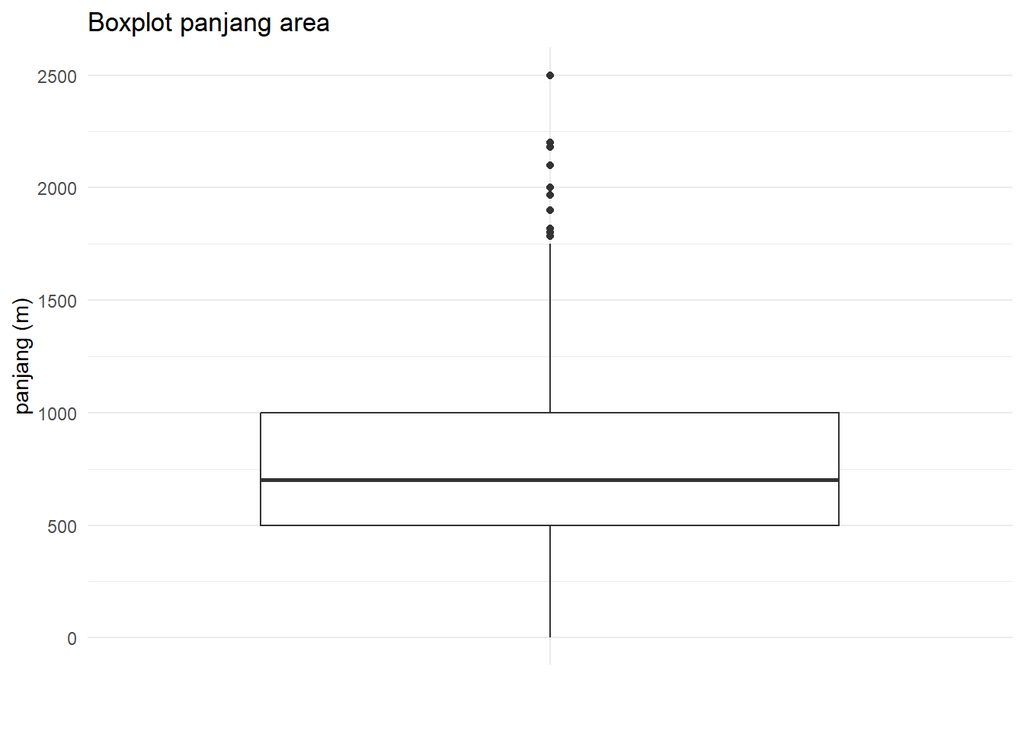

```r
ggplot(dt13, aes(x = "", y = panjang)) +
  geom_boxplot() +
  labs(title = "Boxplot panjang area", y = "panjang (m)", x = "") +
  theme_minimal()
```

```r
Q1 <- quantile(dt13$panjang, 0.25, na.rm = TRUE)
Q3 <- quantile(dt13$panjang, 0.75, na.rm = TRUE)
IQR_value <- Q3 - Q1

lower_bound <- Q1 - 1.5 * IQR_value
upper_bound <- Q3 + 1.5 * IQR_value

outliers <- dt13 %>%
  filter(panjang < lower_bound | panjang > upper_bound)

nrow(outliers)
```

```
## [1] 2600
```

```r
dt14 <- dt13 %>%
  filter(panjang >= lower_bound & panjang <= upper_bound)
nrow(dt14)
```

```
## [1] 30288
```

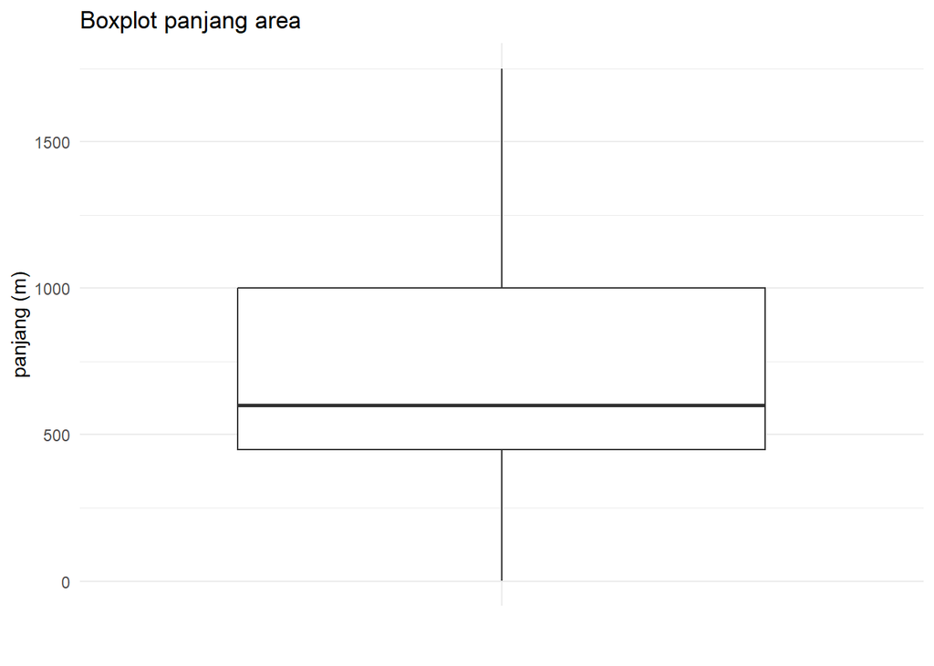

```r
ggplot(dt14, aes(x = "", y = panjang)) +
  geom_boxplot() +
  labs(title = "Boxplot panjang area", y = "panjang (m)", x = "") +
  theme_minimal()
```

#####cek sum

```r
summary(dt14)
```

```
##      bulan   titik_lokasi        kecamatan           wilayah
##  Min.   :1   Length:30288       Length:30288       Length:30288
##  1st Qu.:1   Class :character   Class :character   Class :character
##  Median :1   Mode  :character   Mode  :character   Mode  :character
##  Mean   :1
##  3rd Qu.:1
##  Max.   :1
##     panjang       satuan_panjang.luas    tanggal      volume_sampah_perhari.m3.
##  Min.   :   2.5   Length:30288        Min.   : 1.00   Min.   : 0.000
##  1st Qu.: 450.0   Class :character    1st Qu.: 8.00   1st Qu.: 0.000
##  Median : 600.0   Mode  :character    Median :16.00   Median : 1.000
##  Mean   : 701.8                       Mean   :16.02   Mean   : 4.181
##  3rd Qu.:1000.0                       3rd Qu.:24.00   3rd Qu.:12.000
##  Max.   :1750.0                       Max.   :31.00   Max.   :69.000
```

# Outlier kolom volume sampah

##### cek outlier

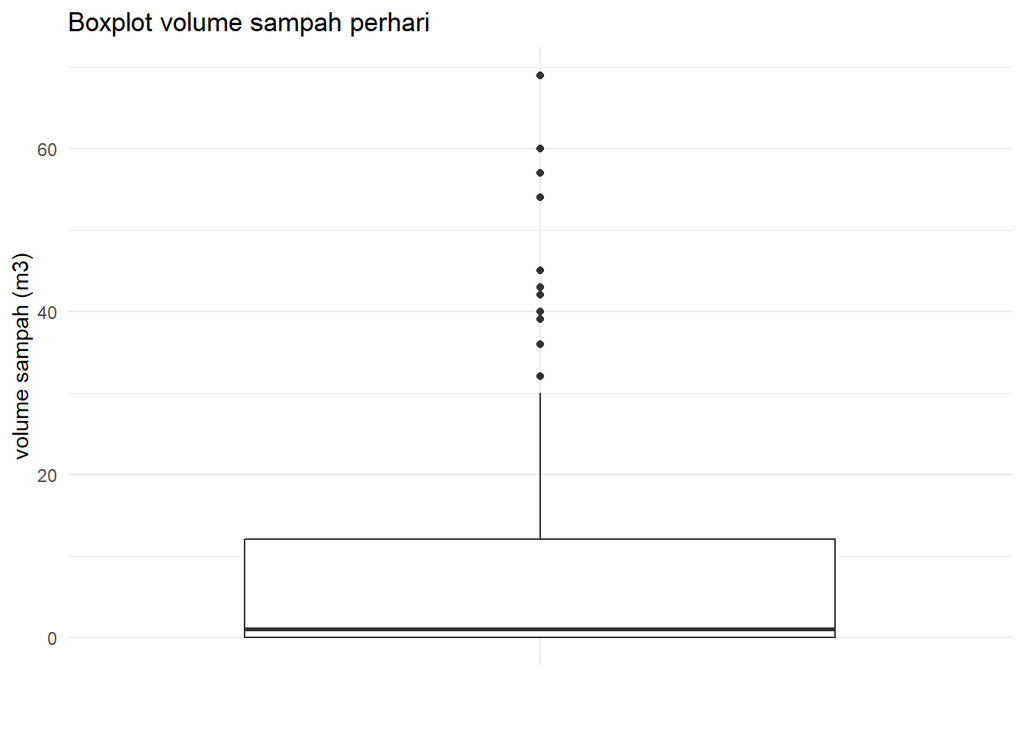

```r
ggplot(dt14, aes(x = "", y = volume_sampah_perhari.m3.)) +
  geom_boxplot() +
  labs(title = "Boxplot volume sampah perhari", y = "volume sampah (m3)", x = "") +
  theme_minimal()
```

pake iqr

```r
Q1 <- quantile(dt14$volume_sampah_perhari.m3., 0.25, na.rm = TRUE)
Q3 <- quantile(dt14$volume_sampah_perhari.m3., 0.75, na.rm = TRUE)
IQR_value <- Q3 - Q1

lower_bound <- Q1 - 1.5 * IQR_value
upper_bound <- Q3 + 1.5 * IQR_value

outliers <- dt14 %>%
  filter(volume_sampah_perhari.m3. < lower_bound | volume_sampah_perhari.m3. > upper_bound)

nrow(outliers)
```

```
## [1] 32
```

##### hapus outlier

```r
dt15 <- dt14%>%
  filter(volume_sampah_perhari.m3. >= lower_bound & volume_sampah_perhari.m3. <= upper_bound)
nrow(dt15)
```

```
## [1] 30256
```

##### cek lagi setelah dihapus

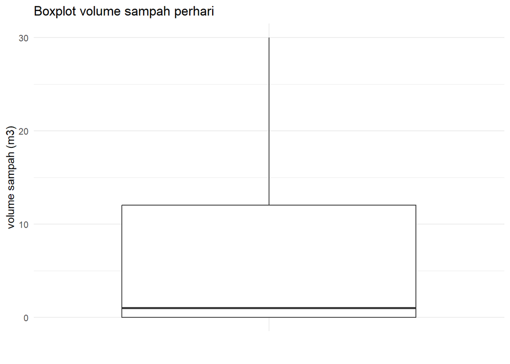

```r
ggplot(dt15, aes(x = "", y = volume_sampah_perhari.m3.)) +
  geom_boxplot() +
  labs(title = "Boxplot volume sampah perhari", y = "volume sampah (m3)", x = "") +
  theme_minimal()
```

# cek kolom data kategorik

##### coba cek jumlah data perwilayah

```r
jumlah_per_wilayah <- dt15 %>%
  group_by(wilayah) %>%
  summarize(jumlah = n())

jumlah_per_wilayah
```

```
## # A tibble: 5 × 2
##   wilayah         jumlah
##   <chr>            <int>
## 1 Jakarta Barat     8661
## 2 Jakarta Pusat     3964
## 3 Jakarta Selatan   3641
## 4 Jakarta Timur     2646
## 5 Jakarta Utara    11344
```

```r
summary(dt15)
```

```
##      bulan   titik_lokasi        kecamatan           wilayah
##  Min.   :1   Length:30256       Length:30256       Length:30256
##  1st Qu.:1   Class :character   Class :character   Class :character
##  Median :1   Mode  :character   Mode  :character   Mode  :character
##  Mean   :1
##  3rd Qu.:1
##  Max.   :1
##     panjang       satuan_panjang.luas    tanggal      volume_sampah_perhari.m3.
##  Min.   :   2.5   Length:30256        Min.   : 1.00   Min.   : 0.000
##  1st Qu.: 450.0   Class :character    1st Qu.: 8.00   1st Qu.: 0.000
##  Median : 600.0   Mode  :character    Median :16.00   Median : 1.000
##  Mean   : 702.1                       Mean   :16.02   Mean   : 4.139
##  3rd Qu.:1000.0                       3rd Qu.:24.00   3rd Qu.:12.000
##  Max.   :1750.0                       Max.   :31.00   Max.   :30.000
```

# VISUALISASI DATA

Persentase sampah terbanyak ada di wilayah Jakarta bagian mana.

```r
# Mengelompokkan data berdasarkan wilayah dan menghitung total volume sampah per wilayah
total_sampah_per_wilayah = dt15 %>%
  group_by(wilayah) %>%
  summarise(total_sampah = sum(`volume_sampah_perhari.m3.`, na.rm = TRUE))

# Membuat pie chart interaktif menggunakan plotly
fig = plot_ly(total_sampah_per_wilayah, labels = ~wilayah, values = ~total_sampah, type = 'pie',
               textinfo = 'percent+label',
               marker = list(colors = RColorBrewer::brewer.pal(n = nrow(total_sampah_per_wilayah), name = "Set3"))) %>%
  layout(title = "Distribusi Sampah Per Wilayah Jakarta")

fig
```

[interactive chart not shown]

##### Rata-rata volume sampah per area di Jakarta perharinya dalam m3

```r
# Menghitung rata-rata volume sampah per wilayah
rata_rata_sampah_per_wilayah <- dt15 %>%
  group_by(wilayah) %>%
  summarise(rata_rata_sampah = mean(`volume_sampah_perhari.m3.`, na.rm = TRUE))

# Menentukan palet warna menggunakan RColorBrewer
colors <- brewer.pal(n = nrow(rata_rata_sampah_per_wilayah), name = "Set3")

# Membuat bar plot interaktif menggunakan plotly dengan warna dari RColorBrewer
fig2 <- plot_ly(rata_rata_sampah_per_wilayah,
                x = ~wilayah,
                y = ~rata_rata_sampah,
                type = 'bar',
                marker = list(color = colors)) %>%
  layout(title = "Rata-rata Volume Sampah Per Area di Jakarta Per Hari",
         xaxis = list(title = "Wilayah"),
         yaxis = list(title = "Rata-rata Volume Sampah (m³)"))

fig2
```

[interactive chart not shown]

##### 5 kecamatan dengan total volume sampah terbanyak

```r
# Menghitung total volume sampah per kecamatan dan mengurutkannya
total_sampah_per_kecamatan <- dt15 %>%
  group_by(kecamatan) %>%
  summarise(total_sampah = sum(`volume_sampah_perhari.m3.`, na.rm = TRUE)) %>%
  arrange(desc(total_sampah)) %>%  # Mengurutkan dari yang terbesar
  top_n(5)
```

```r
# Menentukan palet warna menggunakan RColorBrewer
colors_kecamatan <- brewer.pal(n = nrow(total_sampah_per_kecamatan), name = "Set1")

# Membuat bar plot interaktif untuk 5 kecamatan terbanyak
fig3 <- plot_ly(total_sampah_per_kecamatan,
                x = ~factor(kecamatan, levels = total_sampah_per_kecamatan$kecamatan), # Urutkan sumbu x
                y = ~total_sampah,
                type = 'bar',
                marker = list(color = colors_kecamatan)) %>%
  layout(title = "5 Kecamatan dengan Total Volume Sampah Terbanyak",
         xaxis = list(title = "Kecamatan"),
         yaxis = list(title = "Total Volume Sampah (m³)"))

fig3
```

[interactive chart not shown]

##### Total sampah terbanyak ada di tanggal berapa

```r
# Menghitung total volume sampah per tanggal
total_sampah_per_tanggal <- dt15 %>%
  group_by(tanggal) %>%
  summarise(total_sampah = sum(`volume_sampah_perhari.m3.`, na.rm = TRUE)) %>%
  arrange(desc(total_sampah))

# Menentukan palet warna menggunakan RColorBrewer
colors_tanggal <- brewer.pal(n = nrow(total_sampah_per_tanggal), name = "Set2")
```

```r
# Membuat bar plot interaktif untuk total sampah per tanggal
fig4 <- plot_ly(total_sampah_per_tanggal,
                x = ~tanggal,
                y = ~total_sampah,
                type = 'bar',
                marker = list(color = colors_tanggal)) %>%
  layout(title = "Total Sampah Per Tanggal",
         xaxis = list(title = "Tanggal"),
         yaxis = list(title = "Total Volume Sampah (m³)"))

fig4
```

[interactive chart not shown]

```r
# Menghitung total volume sampah per tanggal dan menyaring data untuk tanggal 1 sampai 31
total_sampah_per_tanggal <- dt15 %>%
  group_by(tanggal) %>%
  summarise(total_sampah = sum(`volume_sampah_perhari.m3.`, na.rm = TRUE)) %>%
  # Memastikan hanya tanggal 1 sampai 31 yang disertakan, jika tanggal berupa format dd-mm-yyy
  filter(as.numeric(substr(tanggal, 1, 2)) >= 1 & as.numeric(substr(tanggal, 1, 2)) <= 31) %>%
  arrange(tanggal)  # Mengurutkan berdasarkan tanggal

# Menentukan palet warna menggunakan RColorBrewer
colors_tanggal <- brewer.pal(n = nrow(total_sampah_per_tanggal), name = "Set2")
```

```r
# Membuat grafik garis interaktif untuk total sampah per tanggal (1 sampai 31)
fig41 <- plot_ly(total_sampah_per_tanggal,
                x = ~tanggal,
                y = ~total_sampah,
                type = 'scatter',
                mode = 'lines+markers',  # Menampilkan garis dan marker
                line = list(color = 'rgb(22, 96, 167)', width = 2), # Warna garis
                marker = list(color = 'rgb(255, 99, 71)', size = 8)) %>%
  layout(title = "Total Sampah Per Tanggal (1-31)",
         xaxis = list(title = "Tanggal"),
         yaxis = list(title = "Total Volume Sampah (m³)"))

fig41
```

[interactive chart not shown]

##### Relasi antara panjang area dengan Volume sampah

```r
# Membuat scatter plot untuk menunjukkan relasi antara panjang area dan volume sampah
fig5 <- plot_ly(dt15,
                x = ~panjang,
                y = ~`volume_sampah_perhari.m3.`,
                type = 'scatter',
                mode = 'markers',
                marker = list(color = ~panjang,
                              colorscale = "Viridis",
                              size = 12,
                              showscale = TRUE)) %>%
  layout(title = "Relasi antara Panjang Area dan Volume Sampah",
         xaxis = list(title = "Panjang Area (m)"),
         yaxis = list(title = "Volume Sampah Per Hari (m³)"))

fig5
```

[interactive chart not shown]

panjang area dan volume sampah memang tidak ada hubungan yang linier atau korelasi yang jelas. Meskipun tidak ada outliers, grafik bisa terlihat tersebar luas jika hubungan antara kedua variabelnya tidak terlalu kuat atau tidak mengikuti pola tertentu.

```r
# Menghitung korelasi Pearson
correlation <- cor(dt15$panjang, dt15$`volume_sampah_perhari.m3.`)

# Menampilkan hasil korelasi
cat("Korelasi Pearson antara Panjang Area dan Volume Sampah: ", correlation, "\n")
```

```
## Korelasi Pearson antara Panjang Area dan Volume Sampah:  -0.09209936
```

Scatter plot yang terlihat tersebar luas dan tidak memiliki pola yang jelas sangat sesuai dengan hasil korelasi ini. Korelasi yang rendah ini mengindikasikan bahwa meskipun kita melihat data dalam bentuk scatter plot, hubungan antara panjang area dan volume sampah tidak cukup kuat atau linier untuk dijadikan prediktor.

Data ini mungkin membutuhkan eksplorasi lebih lanjut dengan mempertimbangkan faktor lain yang bisa mempengaruhi volume sampah (misalnya, kepadatan penduduk, jenis area, kebiasaan, atau faktor lain selain panjang area).